# Programming with Python

## Functions and String

#### Instructor: Bishal Rijal

# Functions? Why use functions?

Functions are a group of statements, so they can be run more than once in a program.

Just like a value can be associated with a name, a piece of logic can also be associated with a name by defining a function.

Functions serve two primary development roles:

#### Code reuse

- Functions allow us to group and parametrize chunks of code to be used arbitrarily many times later.

#### Procedural decomposition/Modularity

- Functions also provide a tool for splitting systems into pieces that have a well-defined role.

# Creating custom functions in python

```
def func_name(args):
    #processing
    return result
```

```python
#a simple function to add 2 numbers
def add(a,b):
    return a+b

add(1,2)
```

```
3
```

```python
def subtract(a,b):
    '''a function to subtract 2 numbers'''
    return a-b

def multiply(a,b):
    return a*b

def divide(a,b):
    return a/b
```

```python
subtract.__doc__
```

```
'a function to subtract 2 numbers'
```

```python
def square(x):
    return x * x
```

```python
square(5)
```

```
25
```

### The functions can be used in any expressions.

```python
square(2) + square(3)
```

```
13
```

```python
square(square(3))
```

```
81
```

### Existing functions can be used in creating new functions.

```python
def sum_of_squares(x, y):
    return square(x) + square(y)
```

```python
sum_of_squares(2, 3)
```

```
13
```

### Functions are just like other values, they can assigned, passed as arguments to other functions etc.

```python
f = square
f(4)
```

```
16
```

```python
def fxy(f, x, y):
    return f(x) + f(y)

fxy(square, 2, 3)
```

```
13
```

# Default arguments

```python
def power(x,y=2): #y has a default value
    return x**y

power(3)
```

```
9
```

```python
power(3,3)
```

```
27
```

# Passing arbitrary number of arguments to a function using *args

```python
def add(*args):
    print(args)
    return sum(args)
```

```python
add(1,2)
```

```
(1, 2)
```

```
3
```

```python
add(1,2,3)
```

```
(1, 2, 3)
```

```
6
```

```python
add(1,2,3,4)
```

```
(1, 2, 3, 4)
```

```
10
```

#### What will be the output of the following program?

x = 0  
y = 0  
def incr(x):

```
y = x + 1
```

return y  
incr(5)  
print x, y

```python
x = 0
y = 0
def incr(x):
    y = x + 1
    return y
incr(5)
print(x, y)
```

```
0 0
```

# Variable Scope

- **Global variables** are variables declared **outside functions** and can be accessed from anywhere within the program
- **Local variables** are variables declared **inside a function** and can be used only inside that particular function
- from inside a function, a variable which is defined outside the function can be accessed even if not explicitly passed as arguments
- locals variables cannot be accessed from outside functions

When Python sees use of a variable not defined locally, it tries to find a global variable with that name.

However, you have to explicitly declare a variable as **global** to modify it.

```python
a = 0
def square(x):
    global a
    a = a + 1
    return x * x
```

```python
square(5)
```

```
25
```

```python
a
```

```
1
```

```python
x = 1
def f():
    return x
print (x)
print (f())
```

```
1
1
```

```python
x = 1
def f():
    x = 2
    return x
```

```python
print(x)
print(f())
print(x)
```

```
1
2
1
```

```python
x = 1
def f():
    global x
    y = x
    x = 2
    return x + y
print(x)
print(f())
print(x)
```

```
1
3
2
```

#### What will be the output of the following program?

x = 1  
def f():

```
    y = x
    x = 2
    return x + y
```

print(f())

```python
x = 1
def f():
    x = x+1
    return x
print(f())  #by default global variables cannot be modified from inside functions
```

```
---------------------------------------------------------------------------
UnboundLocalError                         Traceback (most recent call last)
Cell In[26], line 5
      3     x = x+1
      4     return x
----> 5 print(f())

Cell In[26], line 3, in f()
      2 def f():
----> 3     x = x+1
      4     return x

UnboundLocalError: cannot access local variable 'x' where it is not associated with a value
```

```python
x = 1
def f():
    global x
    x = x+1
    return x
print(f())
```

```
2
```

# Solving problems with Recursion

- One way to describe repetition within a computer program is the use of loops, such as python's *while-loop* and *for-loop*.
- An entirely different way to achieve repetition is through a process called ***recursion***.
- Recursion is a technique by which a function makes one or more calls to itself during execution.
- In computing, recursion provides an elegant and powerful alternative for performing repetitive tasks.
- When one invocation of the function makes a recursive call, that invocation is suspended until the recursive call completes.

```python
# iterative appoarch
def factorial_iterative(n):
    fact = 1
    for i in range(n,0,-1):
        fact*=i
    return fact

factorial_iterative(5)
```

```
120
```

### A natural recursive definition for the factorial function.

$$ 5! = 5.(4.3.2.1) = 5.4! $$

More generally, for a positive integer $n$, we can define $n!$ to be $n.(n-1)!$

\begin{equation*} n! = \begin{cases} 1 &\text{if n = 0 }\\ n.(n-1)! &\text{if n>= 1} \end{cases} \end{equation*}

- The definition is typical of many recursive definitions.
- First it contains one or more ***base cases***, in this case $n=0$ is the base case.
- It also contains one or more ***recursive cases***, which are defined by appealing to the definition of the function being defined.

```python
# recursive implementation
def factorial_recursive(n):
    if n == 0:
        return 1
    else:
        return n*factorial_recursive(n-1)

factorial_recursive(5)
```

```
120
```

# Recursive algorithm for computing powers

- Compute the power function, defined as `power(x,n) = x^n`
- Observe the fact that $x^n = x.x^{n-1}$ for $n>0$

\begin{equation*} power(x,n) = \begin{cases} 1 &\text{if n = 0 }\\ x.power(x,n-1) &\text{otherwise} \end{cases} \end{equation*}

```python
def power(x,n):
    if n == 0:
        return 1
    else:
        return x * power(x,n-1)

power(2,4)
```

```
16
```

# Calculate the value of $c$

#### $c = 2(a-b)/(a+b)$

#### $a = 2, b = 5$

```python
a = 2
b = 5
```

```python
divide(multiply(2,subtract(a,b)),add(a,b))
```

```
(2, 5)
```

```
-0.8571428571428571
```

## Built-in Functions

#### The Python built-in functions are defined as the functions whose functionality is pre-defined in Python.

#### Example:

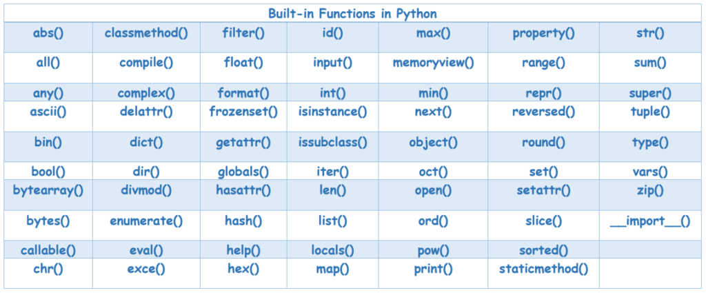

```python
min(2, 3, 4, 1)
```

```
1
```

```python
max(2, 3, 4, 1)
```

```
4
```

```python
len("helloworld")
```

```
10
```

```python
'''The built-in function int converts string to ingeter and built-in function str converts integers and other type
of objects to strings.'''
int("50")
```

```
50
```

```python
str(123)
```

```
'123'
```

Write a function product to find the product of two numbers. Also write another function factorial to compute factorial of a number. Can you use the product function to compute factorial?

```python
def product(a,b):
    return a*b
def factorial(n):
    if n==1:
        return 1;
    else:
        return product(n,factorial(n-1))
```

```python
factorial(5)
```

```
120
```

## Python Lambda/Anonymous Function

#### In Python, a lambda function is a special type of function without the function name.

#### A lambda function can take any number of arguments, but can only have one expression.

### Syntax

#### lambda arguments : expression

```python
greet=lambda : print('Hello World')
greet()
```

```
Hello World
```

```python
x = lambda a : a + 10
print(x(5))
```

```
15
```

##### Write a lambda function to calculate cube of a number

```python
cube = lambda a : a * a * a
print(cube(5))
```

```
125
```

```python
greet1=lambda name: print("hello", name)
greet1('ram')
```

```
hello ram
```

### Lambda functions can take any number of arguments:

```python
x = lambda a, b, c : a * b * c
print(x(5, 6, 2))
```

```
60
```

## Why Use Lambda Functions?

#### The power of lambda is better shown when you use them as an anonymous function inside another function.

#### Say you have a function definition that takes one argument, and that argument will be multiplied with an unknown number:

```python
def myfunc(n):
  return lambda a : a * n
```

```python
# To use that function definition to make a function that always doubles the number you send in
double_value=myfunc(2)
print(double_value(10))
```

```
20
```

```python
# To use that function definition to make a function that always triples the number you send in
double_value=myfunc(3)
print(double_value(10))
```

```
30
```

# Strings

- A string is a ***sequence of characters.***
- Indices work the same way as in lists/tuples.
- Characters can be accessed one at a time with the bracket operator.

```python
s = "banana"
s
```

```
'banana'
```

```python
s[0]
```

```
'b'
```

```python
s[-1]
```

```
'a'
```

```python
len(s)
```

```
6
```

```python
s[len(s)-1]
```

```
'a'
```

## Iterating through strings

```python
i = 0
while i < len(s):
    print(s[i])
    i += 1
```

```
b
a
n
a
n
a
```

```python
for i in range(len(s)):
    print(s[i])
```

```
b
a
n
a
n
a
```

```python
for each in s:
    print(each)
```

```
b
a
n
a
n
a
```

## Strings are immutable

```python
greeting = "Hello world!"
```

```python
greeting[0] = "h" #cannot change a string
```

```
---------------------------------------------------------------------------
TypeError                                 Traceback (most recent call last)
Cell In[57], line 1
----> 1 greeting[0] = "h"

TypeError: 'str' object does not support item assignment
```

```python
new_greeting = "h" + greeting[1:] #create a new string that is a variation of the origional
new_greeting
```

```
'hello world!'
```

## Looping and Counting

```python
word = 'apple'
count = 0
for letter in word:
    if letter == 'p':
        count += 1
count
```

```
2
```

## String methods

```python
word = 'banana'
word.upper()
```

```
'BANANA'
```

```python
word.lower()
```

```
'banana'
```

```python
word.count('a')
```

```
3
```

```python
word.count('na') #can count the occurences of substrings as well
```

```
2
```

```python
word.replace('a','A')
```

```
'bAnAnA'
```

```python
word.replace('a','A',1) #specify how many replacements to carry out
```

```
'bAnana'
```

```python
word.replace('na','NA') #can replace substrings as well
```

```
'baNANA'
```

## Split and Join

```python
s = "Words can be seperated in this way."
s
```

```
'Words can be seperated in this way.'
```

```python
words = s.split() #will split according to whitespace
words
```

```
['Words', 'can', 'be', 'seperated', 'in', 'this', 'way.']
```

```python
" ".join(words)
```

```
'Words can be seperated in this way.'
```

```python
"_".join(words)
```

```
'Words_can_be_seperated_in_this_way.'
```

# Thank you ! Questions?